# Evaluate CliqueSNV Haplotypes

Will Hannon

1/27/2022

The goal of this notebook is to look at the haplotypes outputted by `CliqueSNV` with different parameters over different regions of the genome. I want to determine which parameters are optimal for a given set of tissues. I also want to see how well the tool performs generally. Ideally, I can use the output of this tool to stitch together a set of haplotypes for inference.

## Evaluate CliqueSNV Haplotypes

I first tried to cut the genome in 3000 bp chunks with 2000 bp overlaps. I did this with five different values for minimum O22 count (`t` in `CliqueSNV`) `[20, 40, 80, 120, 360]` and four different values minimum haplotype fraction (`tf` in `CliqueSNV`) `[0.02, 0.05, 0.1, 0.25]`. All of these combinations resulted in a significant fraction of haplotypes that were verifiably false, i.e. haplotypes that contained two mutually exclusive SNPs. There was no clear correlation between values of `t` and `tf` and the fraction of false haplotypes. This led me to suspect that the specificity issue was the result of the size of the region being haplotyped, not the parameters. I re-did this for smaller regions of 500 bp with 250 bp overlaps and two values for `t` (10, and 100) and one value for `tf` (0.05).

### Are there haplotypes that are verifiably false?

I consider a haplotype that is “false” as a haplotype with two mutually exclusive SNPs. I define mutually exclusive SNPs as those which are defined as primary G1 or G2 SNPs or SNPs that have been classied as G1 or G2 while clustering subclonal mutations.

```
## [1] "There are only 1.08 percent of total haplotypes with genome-1 and genome-2 mutations that are verifiably false."
```

```
## # A tibble: 3 × 2
##   Tissue         Interval
##   <chr>          <chr>
## 1 Cerebellum     3049-3549
## 2 Occipital Lobe 4049-4549
## 3 Parietal Lobe  4049-4549
```

The smaller regions work *much* better as an approach to accurately call haplotypes. There are only 3 haplotypes out of ~250 that are verifiably false. Interestingly, these are all pretty much in the same region of the genome (`3049 - 4549`). Is there something special about this region? Perhaps a significant decrease in coverage?

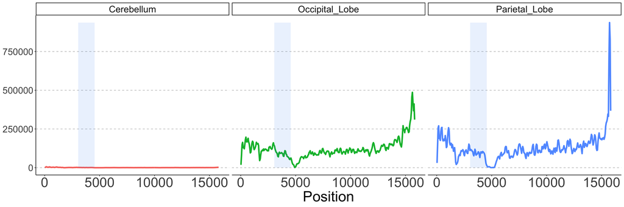

Perhaps it has something to do with the SNPs involved and something is mis-annotated as `genome-1` or `genome-2`? The mis-annotated SNP in the cerebellum probably has something to do with the low coverage and distance from other mutations. I’m not sure what’s going on with the other two. They involve the same mutation - `C4502T`.

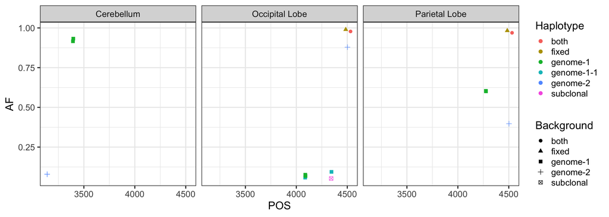

It’s not super clear to me why this mutation would be mis-annotated?

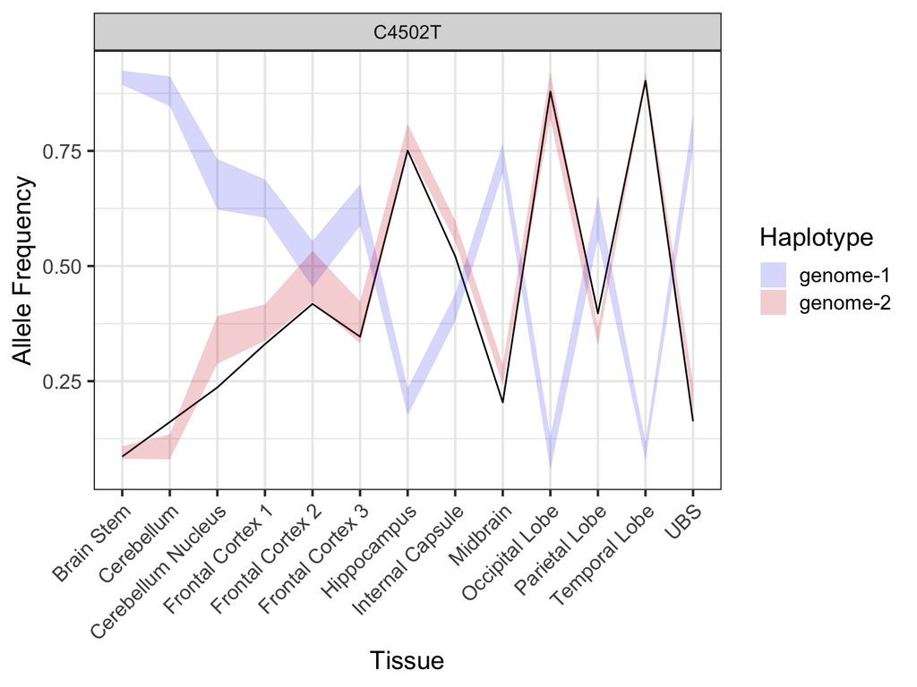